# STAT 440: Homework Assignment #1

Due: Thursday, Jan. 23 at 11:59pm on Canvas

Some of these exercises call for writing code. Please use R, and turn in your code along with your written work and any plots you are asked to produce. Just as you strive for clarity in your writing of language, try to write R code that is easy to read, in the sense that a knowledgeable user of R would be able to understand it easily.

You *may* choose to use LaTeX for your mathematics writing in your homework, in which case I recommend R Markdown as an easy way to combine text, mathematics, R code, and R output. But this is not required; you may choose to format your work however you find convenient, as long as you upload your assignment to Canvas as a single pdf document.

## Exercise 1

*This question is taken directly from the midterm exam for STAT 440 in FA 2023. The purpose of this question is to give you some practice with the style of questions you can expect on an exam.*

The random variable $X = 5 + V$, where $V$ is exponentially distributed with mean $1/4$, has density function $g(x)$ and cdf $G(x)$ as follows:
$$g(x) = 4 \exp \{ -4(x - 5) \} \quad \mbox{and} \quad
G(x) = 1 - \exp \{ -4(x - 5) \}
\quad \mbox{for $x>5$.}$$

If $U\sim\mbox{Unif}(0,1)$ is a standard uniform random variable, what function of $U$ has the same distribution as $X$?

In other words, derive a function $m(U)$ so that setting $X = m(U)$ guarantees that $X$ has the cdf $G(x)$ given above. Explain your work.

### Answer

For this problem, we will need to use the inverse transformation method to derive a function of U that is exactly the CDF above. We are given this CDF of X: $G(x) = 1 - e^{-4(x-5)}$ . The inverse transformation method gives us that if $U\sim\mbox{unif}(0,1)$ then $F^{-1}_X(U)\sim X$ in this case our function is $G(x)$ so we will need to find the inverse of $G(x)$ to find a function of $U$ that gives us the above CDF of $X$.

We will need to solve for x to get the inverse

$G(x) = u$

$1 - e^{-4(x-5)} = u$

$-e^{-4(x-5)} = u - 1$

$e^{-4(x-5)} = 1 - u$

$-4(x-5) = log(1-u)$

$x-5 = -\frac{log(1-u)}{4}$

$x = 5 - \frac{log(1-u)}{4}$

$G^{-1}_X(u) = 5 - \frac{log(1-u)}{4}$

We now have our inverse function of X, if we plug our uniform distribution into the inverse function, we will get exactly the original CDF of X. So this means that $m(U) = G^{-1}_X(U)$To verify this, I will plot both functions.

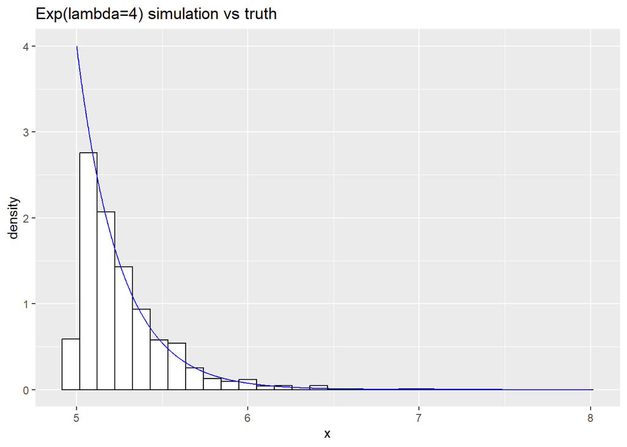

```r
# Step 1: generate uniform samples
unif_samples <- runif(1000, min=0, max=1)

# Step 2: apply inverse transformation
exp_samples <- 5-(log(1 - unif_samples) / 4)

# plot histogram of samples along with true density
ggplot(data=data.frame(x=exp_samples)) +

# create histogram of samples
geom_histogram(mapping=aes(x=x, y=after_stat(density)),
fill="white", color="black", bins=30) +

# add true density using 'dexp' function
geom_line(data = data.frame(x = seq(5, 8, 0.001),
                              y = 4 * exp(-4 * (seq(5, 8, 0.001) - 5))),
            mapping = aes(x = x, y = y), color = "blue") +
ggtitle("Exp(lambda=4) simulation vs truth")
```

## Exercise 2

*This question is taken directly from the midterm exam for STAT 440 in FA 2023. The purpose of this question is to give you some practice with the style of questions you can expect on an exam.*

Cheng is a hypothetical STAT 440 student working on his homework. He writes the R code below, with a few comments to make the code more readable, to help answer a question about rejection sampling:

```r
set.seed (440)   ## Make sure this code is exactly reproducible
f <- function(x) { return (6 * x * (1 - x) ) }   ## x must be between 0 and 1
c <- f(0.5)   ## I checked using calculus that this must be the maximum value of f(x)
g <- 1   ## The uniform (0, 1) density is a constant 1
U <- runif(5000)
ratios <- f(U) / (c * g)
keep <- (runif(5000) < ratios)
Xsample <- U[keep]
length(Xsample)   ## This should be approximately (1 / c) * 5000
```

```
## [1] 3344
```

The vector `Xsample` is an i.i.d. sample of size 3344 from some probability density function. Write down this density function, making sure to specify the range of $x$ values where your density function is valid. Explain your reasoning.

### Answer

The Density function is $f_X(x) = 6x(1-x)$ this function is defined on x values between 0 and 1. This is because the function defined as f in the R code is the density function that we are trying to get the sample to follow. This function f is only defined on the unit interval because that is where the graph of the function is above 0, which meets the conditions for a valid PDF.

## Exercise 3

Suppose that $X$ has an exponential distribution with $E(X)=2$. Then its CDF is
$$F_X(x) = \left[ 1 - \exp \{ -x/2 \} \right] I\{ x>0 \}.$$

**Part (a).** Demonstrate that $F_X(x)$ given above is a legitimate CDF, and show how to derive the PDF (probability density function).

*A function $G(x)$ is a legitimate CDF if it is defined on all of $\mathbb{R}$, it is nondecreasing, it is continuous from the right, and its limits $\lim_{x\to-\infty}G(x)$ and $\lim_{x\to\infty}G(x)$ are 0 and 1, respectively.*

**Part (b).** Show how to derive the quantile function $F_X^-(u)$ for $0<u<1$. Is this a true inverse function? In other words, does $F_X^{-1}(u)$ exist?

**Part (c).** Write R code that transforms a vector of `1e6` (one million) values generated from a (pseudo-)random standard uniform distribution into a vector of `1e6` values whose distribution is exponential with mean 2. Explain how you use your answer for part (b).

**Part (d).** Create a histogram of your million exponential values from part (c). Scale the vertical axis so that it uses the density scale (i.e., so that the total histogram area equals 1) and superimpose a graph of the true density function of Exp(mean=2). Somewhere on the plot, print the sample mean and variance of your million values. Comment briefly on what this plot suggests regarding whether the random values appear to have the intended distribution.

**Part (e).** Prove rigorously that your method produces random variables whose true distribution is Exp(mean=2).

**Hint:** Essentially, you should simply reproduce the second part of the proof of the theorem on page 4 of the Week 01a notes. That is, show directly that $F_X^-(U) \sim \mbox{Exp}(\mbox{mean}=2)$ by plugging in the $F_X^-(\cdot)$ function you derived in part (b).

### Answer

**Part (a)** This function is a legitimate cdf because if is defined on all real numbers. This is because the function contains an indicator variable that is 1 if x is greater than 0 or 0 otherwise. This means that for x values greater than 0, the cdf will be defined by $1-e^{-x/2}$ and for all other x values the cdf will be 0. This cdf is also non-decreasing as x goes to infinity. The function is also continuous from the right. I know that it is right continuous because if we evaluate the piece wise function approaching x = 0 from the right, we get $1 - e^0 = 0$ and if we find the value approaching from the left, given by the indicator function, we get 0 as well. Since the limits for both the left and right are the same [0], the function is continuous. Since it is continuous, right continuity is implied. The limit of the function as x goes to negative-infinity, is 0 and the limit as x goes to infinity is 1.

We can find the PDF of the function by taking the derivative of the cdf in terms of x. So we will get $f_X(x) = \frac{1}{2}e^{-x/2} I_{x>0}$ by differentiating $F_X(x)$

**Part (b)** To find the quantile function, it is essentially the same process as finding the inverse of the cdf. After solving, we get a quantile function of $F_X^-(u) = -2log(1 -u)$. This is a true inverse function because the original function $F_X(x)$ is both continuous and strictly increasing, then $F_X^-(x) = F_X^{-1}(x)$ which proves that the quantile function is the true inverse.

**Part (c)**

```r
uniform_samples <- runif(1e6)

exp_samples <- -2 * log(1- uniform_samples)
```

We use our answer from part b to transform the random uniform sample into an exponential distribution with mean two. Because of the inverse transformation method, we can plug a uniformly distributed random variable (U) into the quantile function for variable X which will result in a new variable that follows the same distribution as X. So in this case we are plugging the random uniform samples into the quantile function for $F_X(x)$, so we will get a new distribution that follows Exponential with mean 2.

**Part (d)**

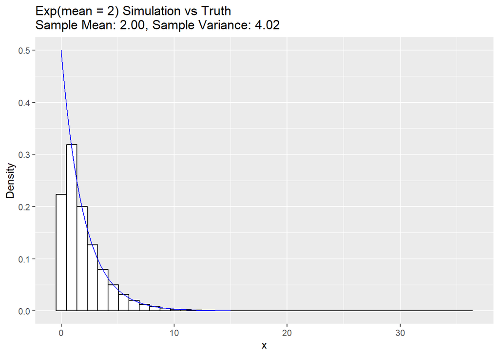

```r
sample_mean <- mean(exp_samples)
sample_var <- var(exp_samples)

ggplot(data = data.frame(x = exp_samples)) +

  # Create histogram of samples
  geom_histogram(mapping = aes(x = x, y = after_stat(density)),
                 fill = "white", color = "black", bins = 40) +

  # Add true density using 'dexp' function
  geom_line(data = data.frame(x = seq(0, 15, 0.001),
                              y = (1 / 2) * exp(-seq(0, 15, 0.001) / 2)),
            mapping = aes(x = x, y = y), color = "blue") +

  # Add a title to the plot
  ggtitle(sprintf("Exp(mean = 2) Simulation vs Truth\nSample Mean: %.2f, Sample Variance: %.2f",
                  sample_mean, sample_var)) +

  xlab("x") + ylab("Density")
```

This plot suggests that the histogram of the million random samples taken from the uniform distribution follow the exponential model with a mean of 2 when they are plugged into the quantile function found in part b.

**Part (e)** Suppose we have random variable $U \sim\mbox{unif}(0,1)$ which is equal to the cdf $F_X(x)$ evaluated at the random variable X, so $U = F_X(X)$. We found the inverse of $F_X(x)$ in part b, $F^{-1}_X(u) = -2log(1-u)$. We also have the exponential random variable $X \sim\mbox{expo}(mean =2)$ which has mean 2. To prove that our method produces random variables whos true distribution is X [expo(mean = 2)], we need to plug the uniform distribution into the inverse. We will get $F_X^{-1}(U)$ which is equivalent to $F_X^{-1}(F_X(X))$. So in this specific case plugging the functions into each other will yield:

$-2log(1 - [1-e^{-X/2}])$

$-2log(1 - 1+e^{-X/2})$

$-2log(e^{-X/2})$

$-\frac{X}{2} * -2log(e)$

$X$

We are left with just the random variable X which know from before follows the distribution of expo(mean = 2), therfore we prove that the sample of the uniform resulted in the correct distribution.

## Exercise 4

This exercise combines the inverse sampling technique for generating standard exponential variables (from Exercise 3) with rejection sampling (from the Week01b notes) to generate half-normal random variables. The half-normal density function is $\[f(y) = \frac{2}{\sqrt{2\pi}} \exp \left \{ -\frac{y^2}{2} \right \} I\{y>0\}.\]$ We’ll call $f(y)$ the target PDF and let g(y) denote the PDF of the proposal distribution, which in this case is standard exponential.

**Part (a).** First, find the smallest possible constant $c$ such that $f(x) / cg(x)$ is less than or equal to 1 for any $x>0$. Show your work.

**Part (b).** Explain how to modify the method from Exercise 3 so that it produces values sampled from standard exponential. (“Standard” here means that the mean equals 1.)

**Part (c).** Write code that will generate 10,000 standard exponentials along with 10,000 standard uniforms. Consider the exponential variable values to be the proposed half-normal values. For each proposal $X$ and corresponding uniform $U$, reject the proposal whenever $U > f(X) / cg(X)$, where $c$ is the constant you found in part (a). What fraction of your proposals do you accept, and how does this fraction compare to $1/c$?

Alternative approach to Part (c); you can choose which to use: Write code that will generate 10,000 standard exponentials. Consider the exponential variable values $X$ to be the proposed half-normal values. Generate 10,000 Bernoulli variables (using `rbinom` with `size=1`) with parameters $f(X) / cg(X)$, where $c$ is the constant you found in part (a). Accept all $X$ for which the Bernoulli variable equals 1. What fraction of your proposals do you accept, and how does this fraction compare to $1/c$?

**Part (d).** Display your accepted half-normal random values as in Exercise 3(d), using a histogram with the true half-normal density plotted on the same set of axes.

### Answer

**Part (a)** We want to find the smallest value of c such that $\frac{f(x)}{cg(x)} \le 1$ where f(x) will be the pdf of the half-normal distribution and g(x) will be the pdf of the standard exponential distribution. So then we will have the inequality: $\frac{\frac{2}{\sqrt{2\pi}} \exp \left \{ -\frac{x^2}{2} \right \} I\{x>0\}}{c\exp\{-x\}I\{x>0\}} \le 1$ which can be rewritten as $\frac{2}{\sqrt{2\pi}}\exp\{\frac{-x^2}{2}+x\} \le c$. From this rearranging, we see that the constant c must be at most the value of the new ratio. So c needs to be larger than the ratio for all values of x greater than 0. So we must maximize the ratio to obtain the smallest possible value that holds for c. We can take the derivative of the exponent of the ratio, which is $\frac{-x^2}{2}+x$, differentiating this gives $-x + 1$ which means the maximimum occurs at $x = 1$. Then we plug in x = 1 to the ratio from above and get $\frac{2}{\sqrt{2\pi}}\exp \{\frac{1}{2}\} \le c$. So this is the smallest possible value for c.

**Part (b)** We can modify excersice 3 to get values sampled from a standard exponential model. First, we will have to change the original function into the cdf for the standard exponential model. Then we will find the quantile function of that distribution which will be the same as the inverse because the exponential cdf is defined for all real numbers and is strictly increasing. We then can take the same random uniform sample and plug into the quantile function. We should get a new disribution that also follows the standard exponential. This will be the random sample of the standard exponential that we will use.

**Part (c)**

```r
set.seed(440)

f <- function(x) {(2/sqrt(2* pi)) * exp(-x^2/2)} #half normal
g <- function(x) {exp(-x)} #standard expo

c <- (2 / sqrt(2 * pi)) * exp(1 / 2) #value for c calculated in part a

X <- rexp(10000,rate=1)

accept_rate <- f(X)/(c * g(X))

accepted <- rbinom(10000, size = 1, prob = accept_rate)

accepted_vector <- X[accepted == 1]

cat("Acceptance fraction:", length(accepted_vector)/10000, "\n")
```

```
## Acceptance fraction: 0.7549
```

```r
cat("1/c:", 1 / c, "\n")
```

```
## 1/c: 0.7601735
```

As we can see the rates for both of them are very close to eachother

**Part (d)**

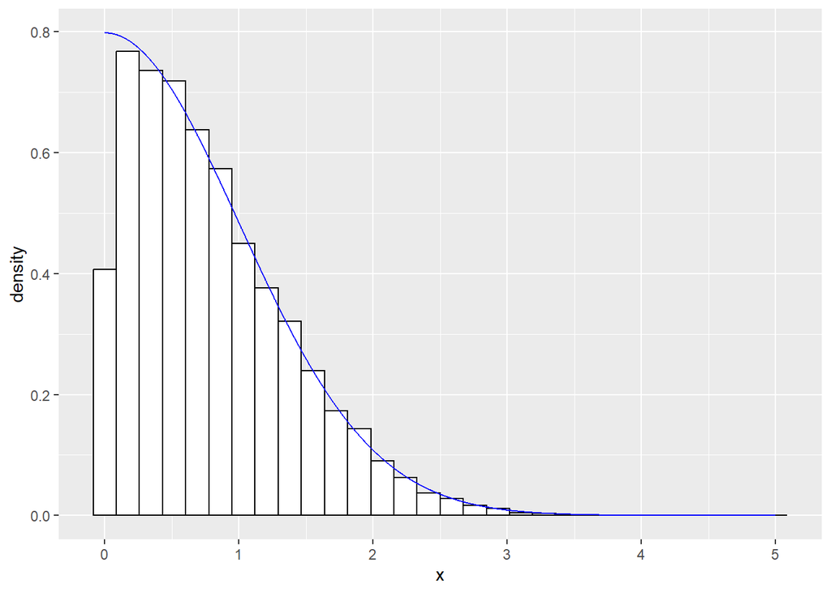

```r
ggplot(data = data.frame(x=accepted_vector)) +
  geom_histogram(mapping = aes(x=x,y = after_stat(density)),
                 fill = "white", color = "black", bins = 30) +
  geom_line(data = data.frame(x = seq(0,5,0.001),
                              y = f(-seq(0,5,0.001))),
            mapping = aes(x=x,y=y), color = "blue")
```